# Ceda Code for example 1

Sabrina Enriquez

10/23/2020

## Code for “Categorical exploratory data analysis on goodness-of-fit issues by Sabrina Enriquez, Fushing Hsieh”

Here we will show the entire CEDA algorithm 1 and 2 from the paper applied to the fly data found at https://seattlecentral.edu/qelp/sets/057/057.html. First we load some useful libraries:

```r
library(data.table)
library(dplyr)
library(ggpubr)
library(dendextend)
library(gplots)
library(ggplot2)
library(NbClust)
library(RColorBrewer)
library(nortest)
```

## Functions

Here we will list functions used throughout the algorithms.

bin_intervals determines bin intervals from our original data.

input: original data and number of clusters K

output: array with K bin intervals

```r
bin_intervals <- function(dataset, clustersK) {
  dd <- dist((dataset), method = "euclidean")
  HC <- hclust(dd, method = "ward.D2")
  #divide data in HC into K clusters
  cut_HC <- cutree(HC, k = clustersK)
  cut_HC_df <- data.frame(cut_HC)
  #create a 2 column matrix: dataset_bin_count showing members and clusters
  dataset_bin_count <- mutate(dataset, cluster = cut_HC)
  # #observed boxes tells us index of arranged data
  # observedboxes<- rect.hclust(HC , k = clustersK, border = 2:6)
  #intervalRange store range values of each interval
  intervalRange <-
    data.frame(
      "clusterMin" = matrix(0, clustersK, 1),
      "clusterMax" = matrix(0, clustersK, 1),
      "cluster" = c(1:clustersK)
    )
  #determine min of data
  minimum <- min(dataset)
  intervalRange[1, 1] <- minimum

  binsByIndex <- data.frame(matrix(0, nrow(dataset), clustersK))
  counter <- matrix(1, 1, clustersK)
  for (j in 1:nrow(dataset)) {
    for (i in 1:clustersK) {
      if (cut_HC_df[j, 1] == i) {
        binsByIndex[counter[1, i], i] <- j
        counter[1, i] <- counter[1, i] + 1
        break
      }
    }
  }

  #matrix of values
  BinsValues <- binsByIndex
  for (j in 1:ncol(binsByIndex)) {
    for (i in 1:nrow(binsByIndex)) {
      if (binsByIndex[i, j] != 0) {
        BinsValues[i, j] <- dataset[binsByIndex[i, j], 1]

      }
    }
  }

  for (i in 1:nrow(intervalRange)) {
    intervalRange[i, 1] <- min(BinsValues[BinsValues[, i] > 0, i]) #min
    intervalRange[i, 2] <- max(BinsValues[, i]) #max
  }

  intervalRange <- intervalRange[order(intervalRange[, 1]), ]
  row.names(intervalRange) <- NULL

  return(intervalRange)
}
```

bincount function gives us a matrix showing how many datum fall into each bin defined by bin_intervals.

input: dataframe that consists of one column bin interval matrix dim: clusterK x 2

output: matrix showing how many objects are in each bin.

```r
bincount <- function(dataset, intervals) {
  #add a column of zeros for cluster column
  dataset_bins <-
    data.frame(dataset, "cluster" = matrix(0, nrow(dataset), 1))

  #according to our bin intervals determine which bin each data is in and store in cluster col of
  #dataset_bins

  for (i in 1:nrow(dataset)) {
    for (j in 1:nrow(intervals))
    {
      if (dataset[i, 1] <= intervals[1, 2])
      {
        dataset_bins[i, 2] <- 1
      }
      if (dataset[i, 1] >= intervals[j, 1] &
          dataset[i, 1] <= intervals[j, 2])
      {
        dataset_bins[i, 2] <- j
      }
      if (dataset[i, 1] >= intervals[nrow(intervals), 1])
      {
        dataset_bins[i, 2] <- nrow(intervals)
      }
    }
  }

  #create vector totals that counts how many members in each bin

  totals_in_bins <-
    setNames(data.frame(matrix(0, nrow(intervals), 1)), names(dataset))
  for (i in 1:nrow(dataset))
  {
    totals_in_bins[dataset_bins[i, 2], 1] <-
      totals_in_bins[dataset_bins[i, 2], 1] + 1
  }


  return(totals_in_bins)

}
```

diffMatrixGivenSims gives us a difference matrix of pre-simulated data.

Input: bincount matrix and bin intervals.

Output: difference matrix for data.

```r
diffMatrixGivenSims<- function(bincount_matrix, intervals)
{

  observedbincounts<-data.matrix(bincount_matrix[2])


  diff_matrix<-data.matrix(bincount_matrix)

  for(j in 1:nrow(intervals)){

    for (i in 2:(ncol(bincount_matrix))){
      diff_matrix[[j,i]]=diff_matrix[[j,i]]-observedbincounts[[j,1]]
    }
  }

  for(i in 1: nrow(diff_matrix)) #replace values by {0,1,-1}
  {
    for(j in 1: ncol(diff_matrix))
    {
      if(diff_matrix[i,j]<0) #neg values -> -1
      {
        diff_matrix[i,j]<- -1
      }
      if(diff_matrix[i,j]>0) #pos values -> 1
      {
        diff_matrix[i,j]<- 1
      }
    }
  }

  return(diff_matrix)
}
```

diffMatrix will first simulate data from the observed and then give us the difference matrix.

input: number of simulations, observed dataframe, intervals

output: bincount differences between simulations and observed data bin by bin

```r
diffMatrix <- function(simNum, df, intervals)
{
  dataAndSims = data.frame(df)
  for (i in 1:simNum) {
    simulation <-
      data.frame("sim" = round(rnorm(
        nrow(df), mean = mean(df[[1]]), sd = sd(df[[1]])
      )))
    simulation <- arrange(simulation, simulation)
    dataAndSims <- cbind(dataAndSims, simulation)

  }


  bincount_matrix <- data.frame("cluster" = c(1:nrow(intervals)))

  for (i in 1:(simNum + 1)) {
    bincount_matrix <-
      cbind(bincount_matrix, bincount(dataAndSims[i], intervals))
  }

  observedbincounts <- data.matrix(bincount_matrix[2])


  diff_matrix <- data.matrix(bincount_matrix)

  for (j in 1:nrow(intervals)) {
    for (i in 2:(simNum + 2)) {
      diff_matrix[[j, i]] = diff_matrix[[j, i]] - observedbincounts[[j, 1]]
    }
  }

  return(diff_matrix)
}
```

Here we find the P-odds of individual leaves. We will use these in other functions.

```r
allPaths <- function(dend)
{
  subtrees <- partition_leaves(dend)
  leaves <- subtrees[[1]]

  pathRoutes <- function(leaf) {
    which(sapply(subtrees, function(x)
      leaf %in% x))
  }

  paths <- lapply(leaves, pathRoutes)

  return(paths)
}

# get the path of leaf: nodes in order when you go from top to bottom

podds <- function(vec) {
  odd <- 1
  for (i in 2:length(vec)) {
    odd <- odd * (vec[i] / (vec[i - 1] - vec[i]))
  }

  return(odd)

}

## compute the p-odds based on the leaf's nodes number across the path

get_podds_leaf <- function(paths, dend) {
  nodes.num <- lapply(1:length(paths), function(which.leaf) {
    return(get_nodes_attr(dend, "members", id = paths[[which.leaf]]))

  })## get the nodes number across the paths for each leaf


  podds_leaf <- sapply(1:length(paths), function(which.leaf) {
    return(podds(nodes.num[[which.leaf]]))
  }) ## the p-odds for each leaf

  return(podds_leaf)#list(nodes.num,podds_leaf)

}
```

pvalAndPoddsLeaf gives us the p-value and p-odds of our observed data- one of the leaves of the HC.

input: HC: hierarchical cluster object. observedVecLength: integer corresponding to the number of leaves (aka observations) you want the p-value and p-odds of. They must be the first observations in the matrix used to compute HC.

output: the p-value and P-odds of the leaves corresponding to the first observedVecLength observations in the matrix that created HC.

```r
pvalAndPoddsLeaf<- function(HC, observedVecLength)
{
  dend.obj <- as.dendrogram(HC)
  paths <- allPaths(dend.obj)
  leaves <- labels(HC)
  leaves.podds <- get_podds_leaf(paths, dend.obj)
  ## podds correspond to the leaves in plot
  ## in order from left to right ( not the order for original data!!!!)
  ## the more extreme a leaf is, the p-odds smaller, the most extreme value is 1/(N-1)


  mat <- cbind(leaves, leaves.podds)
  colnames(mat) <- c('leaves', 'PO')
  label.podds <- mat[order(mat[, 1], decreasing = F), ]

  MST.set.PO <- list(bylabels = label.podds, byleaves = mat)
  ## list[[1]] show the POdds corresponding to the order as the original data
  ## list[[2]] shows the POdds corresponding to the order in the dend plot accordingly


  PO_mst_obs <- data.frame(MST.set.PO$bylabels[1, 2])
  if (observedVecLength > 1) {
    for (i in 2:observedVecLength)
    {
      PO_mst_obs <- cbind(PO_mst_obs, MST.set.PO$bylabels[i, 2])
    }
  }
  PO_mst_obs <- t(PO_mst_obs)


  pval <-
    data.frame(length(which(MST.set.PO$bylabels[-c(1:observedVecLength), 2] < PO_mst_obs[1])) /
                 (dim(MST.set.PO$bylabels)[1] - observedVecLength))
  if (observedVecLength > 1) {
    for (i in 2:observedVecLength)
    {
      nextpval <-
        data.frame(length(which(MST.set.PO$bylabels[-c(1:observedVecLength), 2] < PO_mst_obs[i])) /
                     (dim(MST.set.PO$bylabels)[1] - observedVecLength))
      pval <- cbind(pval, nextpval)
    }
  }
  pval <- t(pval)
  colnames(pval) = "pval"
  row.names(pval) <- row.names(PO_mst_obs)
  PO_mst_obs <- cbind(PO_mst_obs, pval)

  return(PO_mst_obs)
}
```

## Implementation for fly data

First let’s look through the traditional tests for normality:

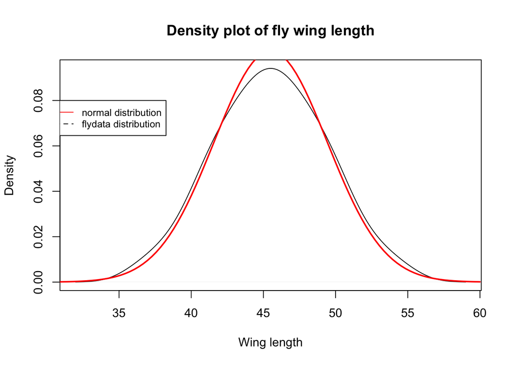

```r
flydatadf <- data.frame(fread('https://seattlecentral.edu/qelp/sets/057/s057.txt'))
colnames(flydatadf)<- "flydata"

#here is the density plot for the data and normal distribution given data's parameters
flydataplot<-density(flydatadf$flydata)
x <- seq(30, 60, length=100)
y <- dnorm(x, mean= 45.5, sd=3.919647)
plot(flydataplot, main = "Density plot of fly wing length",
                       xlab = "Wing length")
lines(x, y, type="l", lwd=2, col="red")
legend(30, .08, legend=c("normal distribution", "flydata distribution"),
       col=c("red", "black"), lty=1:2, cex=0.8)
```

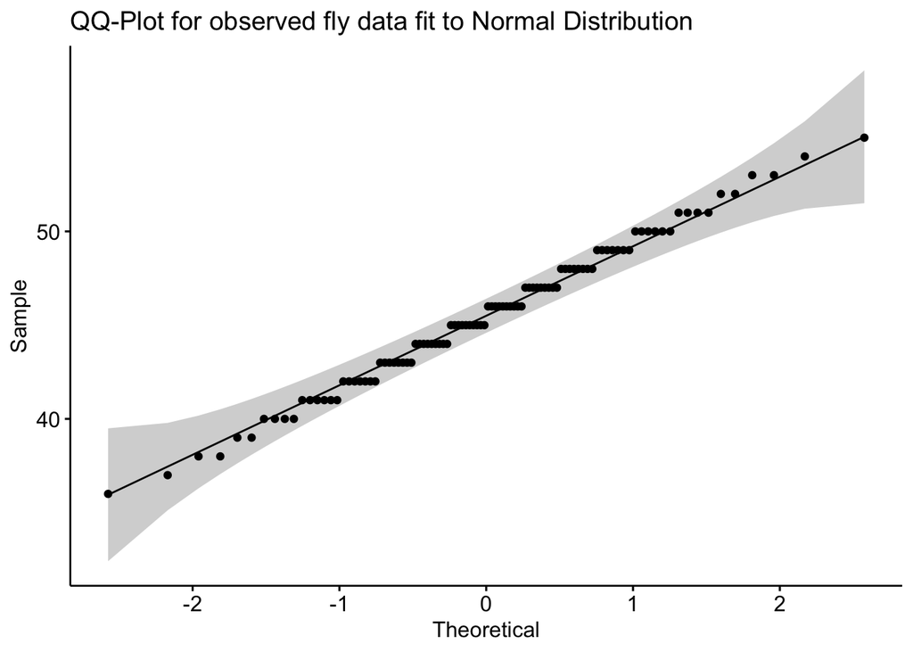

```r
#qq plot for flydata
ggqqplot(flydatadf$flydata, main="QQ-Plot for observed fly data fit to Normal Distribution")
```

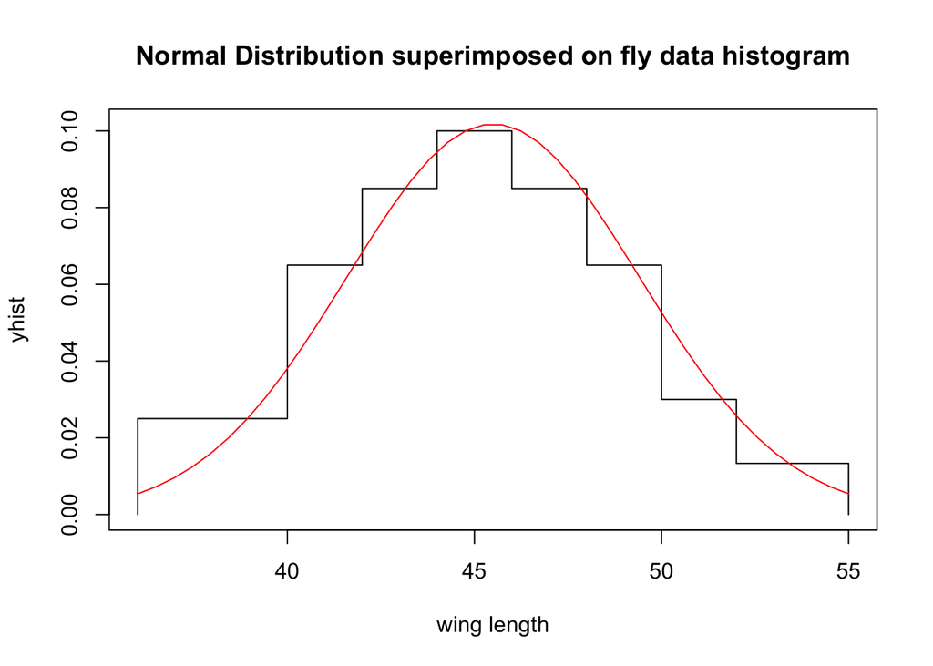

```r
#superimpose normal distribution onto histogram with defined bins
g = flydatadf$flydata
h<-hist(g,breaks=c(36,40,42,44,46,48,50,52,55),  plot= FALSE )
xhist<-c(min(h$breaks),h$breaks)
yhist<-c(0,h$density,0)
xfit<-seq(min(g),max(g),length=40)
yfit<-dnorm(xfit,mean=mean(g),sd=sd(g))
plot(xhist,yhist,type="s",ylim=c(0,max(yhist,yfit)), xlab = "wing length",xlim =c(36,55),main = "Normal Distribution superimposed on fly data histogram")
lines(xfit,yfit, col="red")
```

```r
#shapiro-wilk test
tradPval<-shapiro.test(flydatadf$flydata)
print(tradPval)
```

```
##
##  Shapiro-Wilk normality test
##
## data:  flydatadf$flydata
## W = 0.99281, p-value = 0.8761
```

```r
#chi-squared test: Moore classes number
chi_fly<-pearson.test(as.matrix(flydatadf), n.classes = ceiling(2 * (100^(2/5))), adjust = TRUE)
print(chi_fly)
```

```
##
##  Pearson chi-square normality test
##
## data:  as.matrix(flydatadf)
## P = 11.8, p-value = 0.2987
```

```r
#K-S test

KS_fly<-ks.test(as.matrix(flydatadf), "pnorm", mean=mean(as.matrix(flydatadf)), sd=sd(as.matrix(flydatadf)))
print(KS_fly)
```

```
##
##  One-sample Kolmogorov-Smirnov test
##
## data:  as.matrix(flydatadf)
## D = 0.050752, p-value = 0.9589
## alternative hypothesis: two-sided
```

## Implementing CEDA algorithm 1:

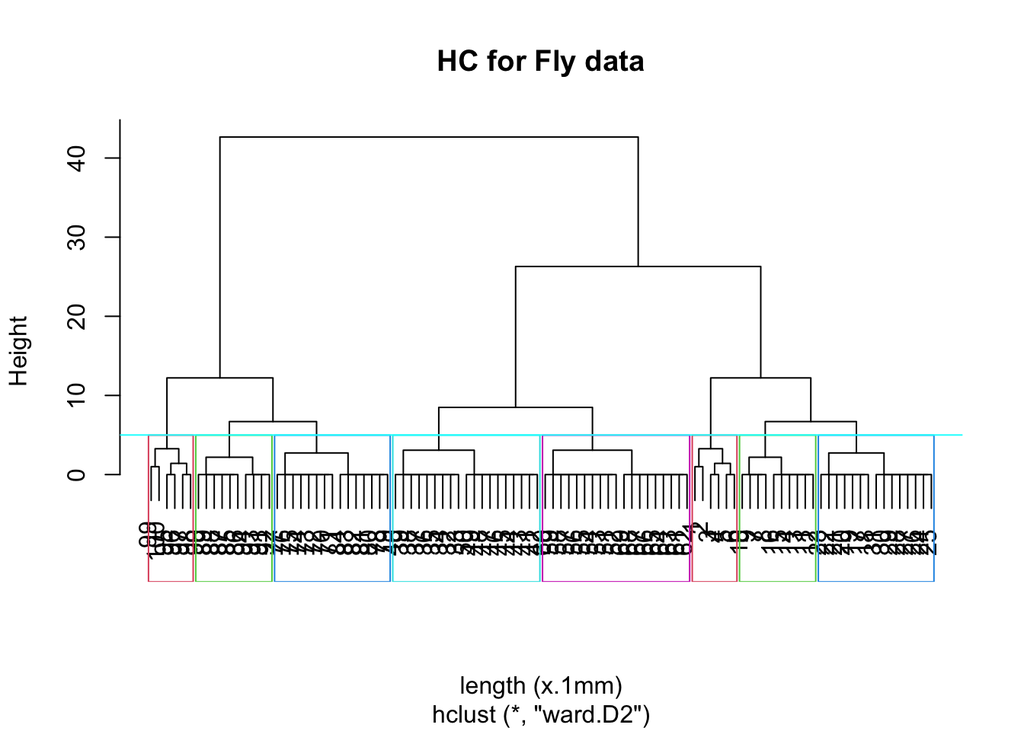

```r
#New method for normality
# Compute distances and hierarchical clustering
dd <- dist((flydatadf), method = "euclidean")
HC <- hclust(dd, method = "ward.D2")
plot(HC, main="HC for Fly data", xlab = "length (x.1mm)")

cut_HC<- cutree(HC, k=8)
plot(HC, main="HC for Fly data", xlab = "length (x.1mm)")
observedboxes<- rect.hclust(HC , k = 8, border = 2:6)
observedcutoff<-abline(h = 5, col = 'cyan')
```

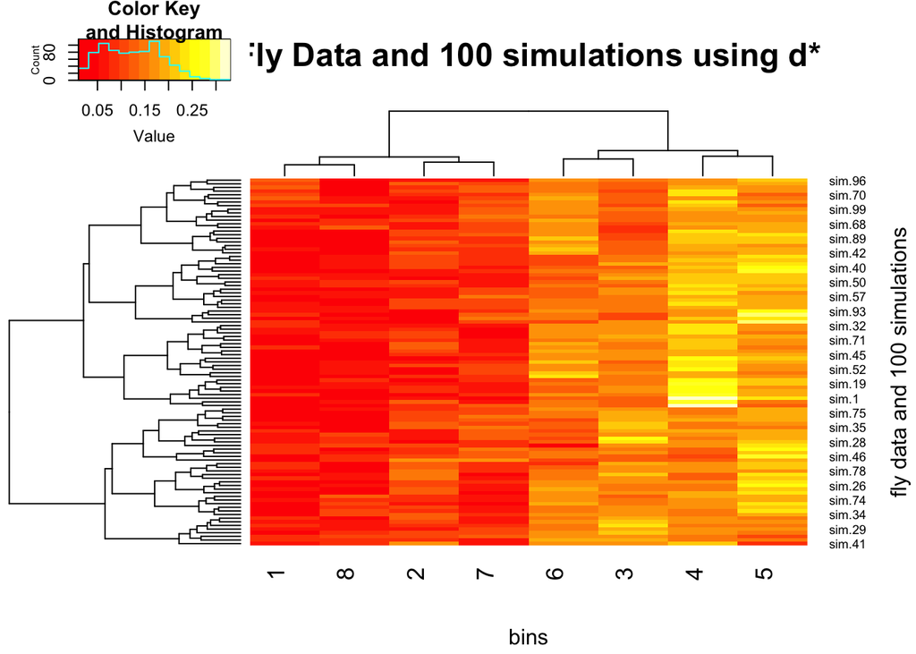

```r
#implement functions

intervals8<- bin_intervals(flydatadf, 8)
bincounts8<- bincount(dataset = flydatadf, intervals8)

#100 simulations

set.seed(100)
flyAnd100= data.frame(flydatadf)
for (i in 1:100) {
  simulation<-data.frame("sim" =round(rnorm(100, mean= 45.5, sd=3.919647)))
  simulation<-arrange(simulation, simulation)
  flyAnd100<-cbind(flyAnd100, simulation)

}


bincount_matrix<- data.frame("cluster"=c(1,2,3,4,5,6,7,8))
for (i in 1:101) {
  bincount_matrix<- cbind(bincount_matrix, bincount(flyAnd100[i], intervals8))
}

arrayBinCount= data.matrix(bincount_matrix[2:102])
PO_matrix<- prop.table(arrayBinCount,2)
tPO<-t(PO_matrix)


#heatmaps for fly data and simulations

theat_fly100d<- heatmap.2(tPO, trace="none",hclustfun = function(x) hclust(x,method = "ward.D2"), ylab = "fly data and 100 simulations",
                          xlab = "bins", main= "Fly Data and 100 simulations using d*")
```

After producing the heatmap from algorithm 1 we can dress it up and highlight our observed vector:

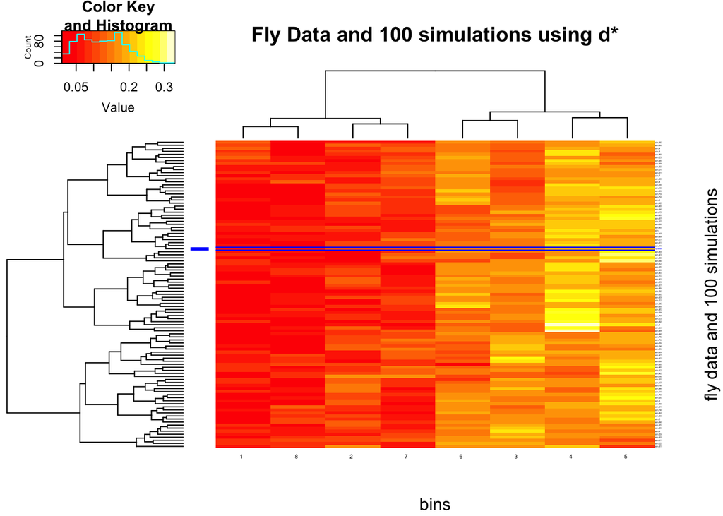

```r
sepval=nrow(tPO)-which(labels(theat_fly100d$rowDendrogram)=="flydata")


theat_fly100d<- heatmap.2(tPO, trace="none",hclustfun = function(x) hclust(x,method = "ward.D2"), ylab = "fly data and 100 simulations",
                          xlab = "bins",cexRow = 0.2,cexCol = 0.5, srtCol=0, offsetCol = 0, offsetRow = -1,RowSideColors = c(rep("blue",1), rep("white",100)), rowsep = c(sepval,sepval+1),sepcolor = "blue", colRow = c(rep("blue",1), rep("black",100)),main= "Fly Data and 100 simulations using d*")
```

```r
#display the p-value and p-odds of our observed data
pvaluefly100<-pvalAndPoddsLeaf(theat_fly100d$rowDendrogram, 1)
print(pvaluefly100)
```

```
##                           PO                 pval
## MST.set.PO.bylabels.1..2. "3.26086956521739" "0.73"
```

## Implementing Algorithm 2

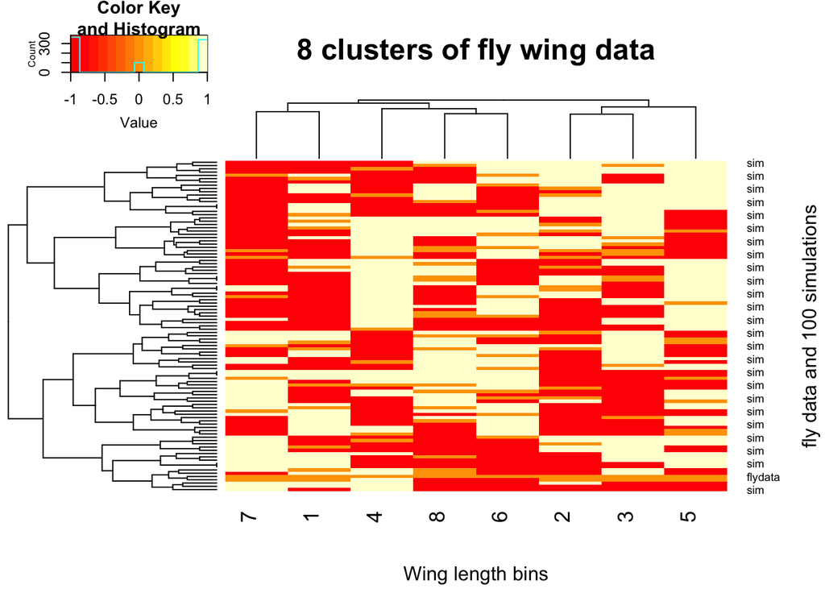

```r
tprotoFly<-diffMatrixGivenSims(bincount_matrix,intervals8)
tprotoFly<-tprotoFly[,-1]
tprotoFly<-t(tprotoFly)


heatmap_flyproto<- heatmap.2(tprotoFly, trace="none", hclustfun = function(x) hclust(x,method = "ward.D2"), xlab = "Wing length bins",
                              ylab = "fly data and 100 simulations", main= "8 clusters of fly wing data")
```

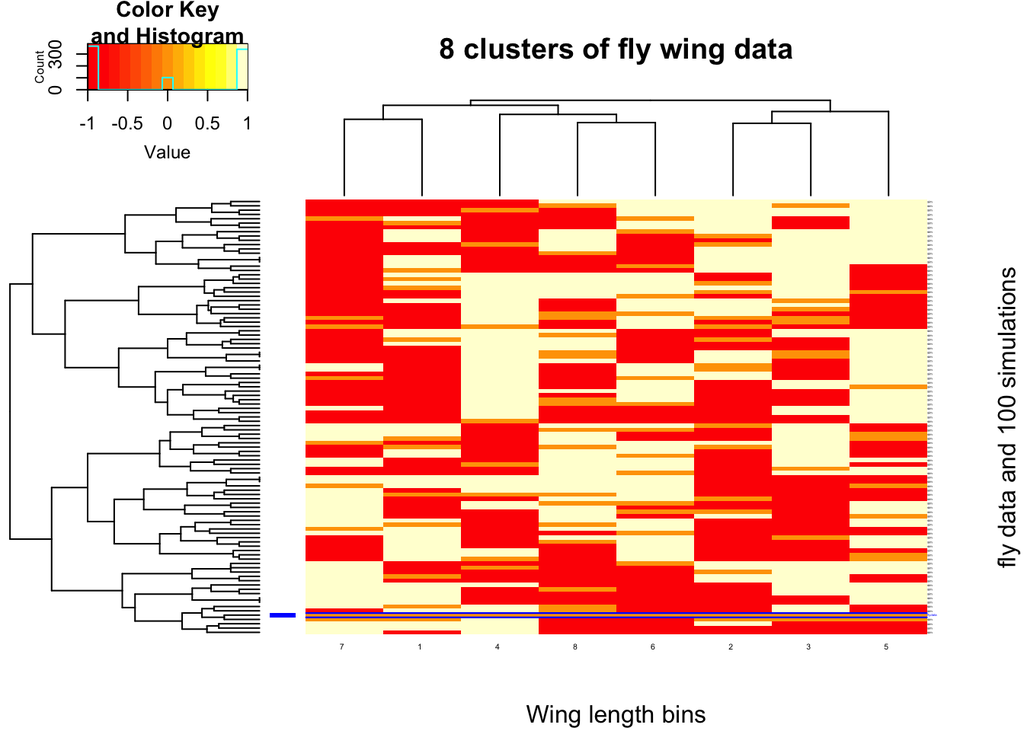

```r
sepval=nrow(tprotoFly)-which(labels(heatmap_flyproto$rowDendrogram)=="flydata")


heatmap_flyproto<- heatmap.2(tprotoFly, trace="none", hclustfun = function(x) hclust(x,method = "ward.D2"), xlab = "Wing length bins",
                              ylab = "fly data and 100 simulations", main= "8 clusters of fly wing data", RowSideColors = c(rep("blue",1), rep("white",(nrow(tprotoFly)-1))),
                              cexRow = 0.2,cexCol = 0.5, srtCol=0, offsetCol = 0, offsetRow = -1, rowsep = c(sepval,sepval+1), sepcolor = "blue", colRow = c(rep("blue",1), rep("black",100)))
```